# simon-5502-06-slides

## Topics to be covered

- What you will learn
  - Review of simple tests of two proportions
  - Concepts behind the logistic regression model
  - Logistic regression with categorical predictors
  - Logistic regression with continuous predictors
  - Logistic regression with interactions
  - Diagnostics

## Comparing two binary outcomes

- Is there a difference in the proportion of deaths between male passengers and female passengers on the Titanic?
- Is there difference in the proportion of patients finishing the full three doses of HPV vaccine between Black women and White women?
- Does using a ng tube for feeding in pre-term infants increase the probability of successful breast feeding at six months?

## Other comparisons involving a binary outcome

- Is there are difference in the proportion of deaths between first class, second class, and third class passengers?
- Does age influence the proportion of women finishing the full three doses of HPV vaccine?
- Controlling for the mother’s age, does using a ng tube for feeding in pre-term infants increase the probability of successful breast feeding at six months?

## The Titanic dataset

```
Rows: 1,313
Columns: 5
$ Name     <chr> "Allen, Miss Elisabeth Walton", "Allison, Miss Helen Loraine"…
$ PClass   <chr> "1st", "1st", "1st", "1st", "1st", "1st", "1st", "1st", "1st"…
$ Age      <dbl> 29.00, 2.00, 30.00, 25.00, 0.92, 47.00, 63.00, 39.00, 58.00, …
$ Sex      <chr> "female", "female", "male", "female", "male", "male", "female…
$ Survived <dbl> 1, 0, 0, 0, 1, 1, 1, 0, 1, 0, 0, 1, 1, 1, 0, 1, 0, 0, 1, 1, 1…
```

## Counts and percentages

```
        Survived
Sex      Yes  No
  female 308 154
  male   142 709
```

```
        Survived
Sex            Yes        No
  female 0.6666667 0.3333333
  male   0.1668625 0.8331375
```

## Test for difference in proportions

```
# A tibble: 1 × 9
  estimate1 estimate2 statistic  p.value parameter conf.low conf.high method
      <dbl>     <dbl>     <dbl>    <dbl>     <dbl>    <dbl>     <dbl> <chr>
1     0.667     0.167      332. 3.43e-74         1    0.450     0.550 2-sample …
# ℹ 1 more variable: alternative <chr>
```

## Chi-square test of independence, 1 of 2

- Equivalent to test of two proportions
- Lay out data in two by two table

$$\begin{matrix}
& No\ event & Event \\
Treatment & O_{11} & O_{12}\\
Control & O_{21} & O_{22}
\end{matrix}$$

## Chi-square test of independence, 2 of 2

$$\begin{matrix}
& No\ event & Event \\
Treatment & E_{11} = n_1 (1-\hat p_.) & E_{12}=n_1 \hat p_.\\
Control & E_{21} = n_2 (1-\hat p_.) & E_{22}=n_2 \hat p_.
\end{matrix}$$

- $X^2=\Sigma \frac{(O_{ij}-E_{ij})^2}{E_{ij}}$

## Expected counts for Titanic

Observed counts

```
        Survived
Sex      Yes  No
  female 308 154
  male   142 709
```

Expected counts

```
        Survived
Sex           Yes       No
  female 158.3397 303.6603
  male   291.6603 559.3397
```

## Chisquare test for Titanic

```
# A tibble: 1 × 4
  statistic  p.value parameter method
      <dbl>    <dbl>     <int> <chr>
1      332. 3.43e-74         1 Pearson's Chi-squared test
```

## Odds ratio calculation

```
       No event  Event  Odds
Group1    a         b
Group2    c         d
```

- Odds for group 1 = $b/a$
- Odds for group 2 = $d/c$
- Odds for group 1 = $\frac{d/c}{b/a} = \frac{ad}{bc}$
- s.e.(log or) = $\sqrt{\frac{1}{a} + \frac{1}{b} + \frac{1}{c} + \frac{1}{d}}$

## Titanic data

```
       Survived   Died  Total
Female   308      154     462
Male     142      709     851
Total    450      863   1,313
```

## Titanic data, odds of death

```
       Survived   Died  Total  Odds
Female   308      154     462  2     to 1 against
Male     142      709     851  4.993 to 1 in favor
Total    450      863   1,313

Odds ratio = 4.993 / 0.5 = 9.986
```

## Odds ratio for survival by sex

```
$data
        Survived
Sex      Yes  No Total
  female 308 154   462
  male   142 709   851
  Total  450 863  1313

$measure
        odds ratio with 95% C.I.
Sex      estimate    lower    upper
  female 1.000000       NA       NA
  male   9.956188 7.662525 13.00928

$p.value
        two-sided
Sex      midp.exact fisher.exact   chi.square
  female         NA           NA           NA
  male            0 4.826448e-74 3.425855e-74

$correction
[1] FALSE

attr(,"method")
[1] "median-unbiased estimate & mid-p exact CI"
```

## Live demo, Review of simple tests of two proportions

## Break #1

- What you have learned
  - Review of simple tests of two proportions
- What’s coming next
  - Concepts behind the logistic regression model

## What is logistic regression?

- Binary outcome
- Categorical or continuous predictors
- Linear on the log odds scale

## Why log odds?

- Statistical model of surgery
  - Estimates probability of demise
  - First prediction: probability=1.2
- Log odds prevent out of range predictions

## A linear model for probability, 1

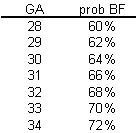

## A linear model of probability, 2

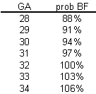

## A multiplicative model for probability

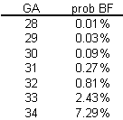

## The relationship between odds and probability

- odds = prob / (1-prob)
- prob = odds / (1+odds)
  - $0 \le$ prob $\le 1$
  - $0 \le$ odds $\le \infty$
    - $0 \le$ odds against $\le 1$
    - $1 \le$ odds in favor $\le \infty$

## A log odds model for probability, 1

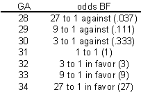

## A log odds model for probability, 2

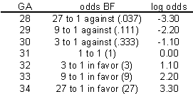

## A log odds model for probability, 3

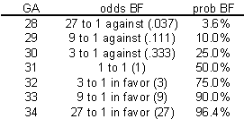

## A log odds model for probability, 4

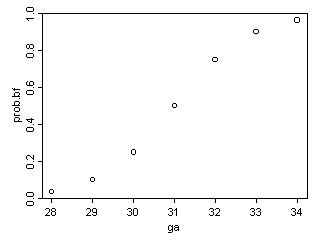

## An example of a log odds model with real data, 1

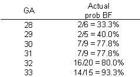

## An example of a log odds model with real data, 2

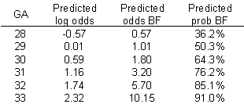

- log odds = -16.72 + 0.577 $\times$ GA

## An example of a log odds model with real data, 3

- log odds = -16.72 + 0.577 $\times$ 30 = 0.59
- odds = exp(log odds) = 1.8
- prob = odds / (1+odds) = 0.64

## Live demo, Concepts behind the logistic regression model

## Break #2

- What you have learned
  - Concepts behind the logistic regression model
- What’s coming next
  - Logistic regression with categorical predictors

## Always start with descriptive statistics

```
# A tibble: 2 × 2
  Sex    pct
  <chr>  <glue>
1 female 35% (462/1313)
2 male   65% (851/1313)
```

```
# A tibble: 3 × 2
  PClass pct
  <fct>  <glue>
1 3rd    54% (711/1313)
2 2nd    21% (280/1313)
3 1st    25% (322/1313)
```

```
# A tibble: 2 × 2
  Survived pct
  <fct>    <glue>
1 Yes      34% (450/1313)
2 No       66% (863/1313)
```

## Compute survival probabilites by sex

```
# A tibble: 2 × 4
# Groups:   Sex [2]
  Sex    Survived pct            odds
  <chr>  <fct>    <glue>        <dbl>
1 female No       33% (154/462)  0.5
2 male   No       83% (709/851)  4.99
```

```
# A tibble: 2 × 4
# Groups:   Sex [2]
  Sex    Survived pct            odds
  <chr>  <fct>    <glue>        <dbl>
1 female Yes      67% (308/462)   2
2 male   Yes      17% (142/851)   0.2
```

## Logistic model estimates

```
# A tibble: 2 × 5
  term        estimate std.error statistic p.value
  <chr>          <dbl>     <dbl>     <dbl> <glue>
1 (Intercept)   -0.693    0.0987     -7.02 p < 0.001
2 Sexmale        2.30     0.135      17.1  p < 0.001
```

- exp(2.3) = 9.99
- exp(2.3-1.96*0.135) = 7.67
- exp(2.3+1.96*0.135) = 13.0

```
# A tibble: 1 × 4
  term    odds_ratio lower upper
  <chr>        <dbl> <dbl> <dbl>
1 Sexmale       9.99  7.67  13.0
```

## Break #3

- What you have learned
  - Logistic regression with categorical predictors
- What’s coming next
  - Logistic regression with continuous predictors

## Always start with descriptive statistics

```
# A tibble: 1 × 4
  age_mean age_sd age_min age_max
     <dbl>  <dbl>   <dbl>   <dbl>
1     30.4   14.3    0.17      71
```

## Logistic regression using Age to predict Survived

```
# A tibble: 2 × 5
  term        estimate std.error statistic p.value
  <chr>          <dbl>     <dbl>     <dbl> <glue>
1 (Intercept)  0.0814    0.174       0.468 p = 0.64
2 Age          0.00879   0.00523     1.68  p = 0.093
```

## Back transform

```
# A tibble: 1 × 4
  term  odds_ratio lower upper
  <chr>      <dbl> <dbl> <dbl>
1 Age         1.01 0.999  1.02
```

## Live demo, Logistic regression with continuous predictors

## Break #4

- What you have learned
  - Logistic regression with continuous predictors
- What’s coming next
  - Logistic regression with interactions

## Line plot, 1

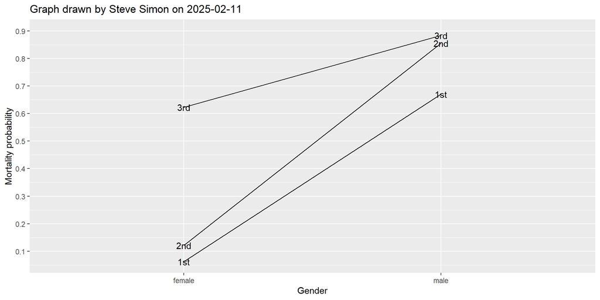

## Line plot, 2

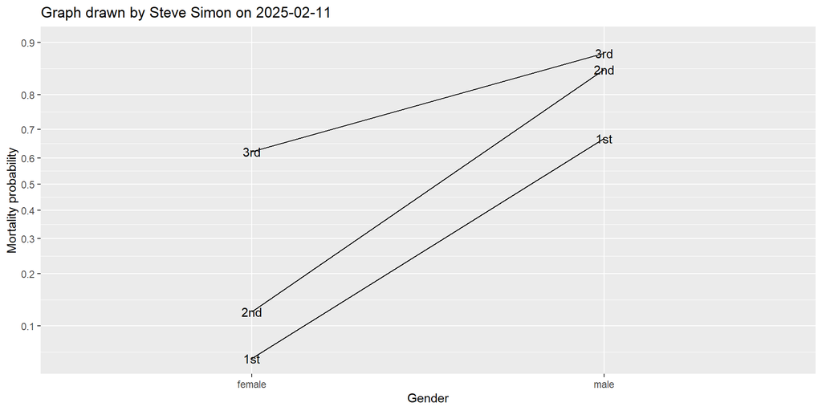

## Line plot, 3

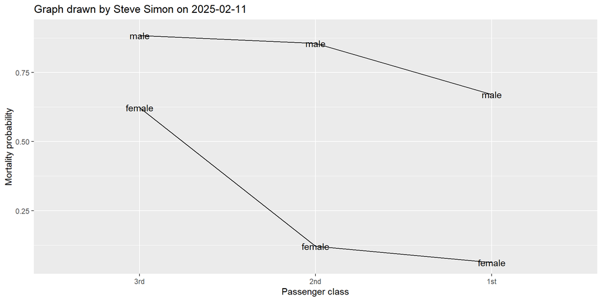

## Line plot, 4

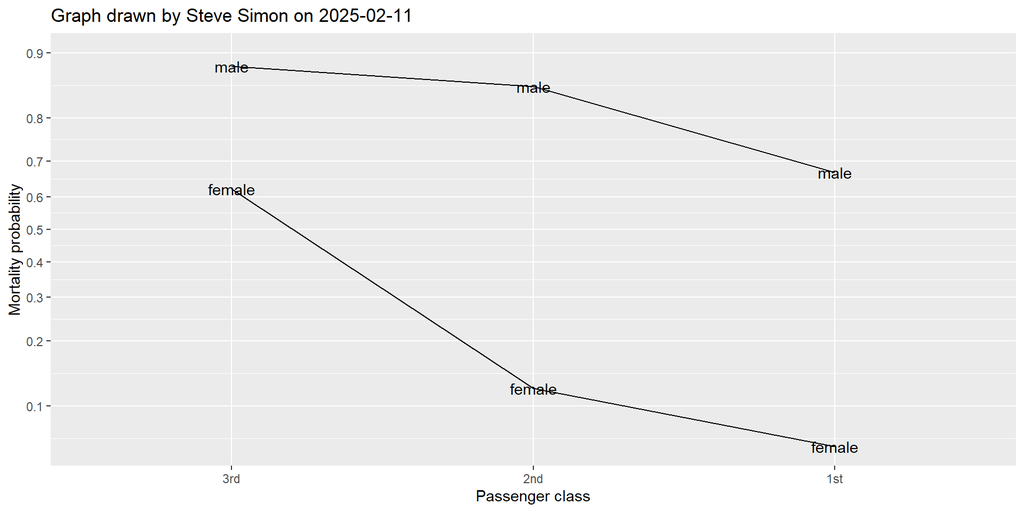

## Logistic regression model with interaction

[output not shown]

## Live demo, Logistic regression with interactions

## Break #5

- What you have learned
  - Logistic regression with interactions
- What’s coming next
  - Diagnostics

## Diagnostics

- Comparison to null model
- Linearity
  - Only for continuous predictors
- Independence
  - Assessed qualitatively

## Live demo, Diagnostics

## Summary

- What you have learned
  - Review of simple tests of two proportions
  - Concepts behind the logistic regression model
  - Logistic regression with categorical predictors
  - Logistic regression with continuous predictors
  - Logistic regression with interactions
  - Diagnostics